# paper1

Kianté Fernandez

10/13/2020

This script contains analyses supporting the manuscript: “Prospect Theory and Judgments About Cognitive Enhancement” by Kianté Fernandez and John Medaglia

This script was prepared by Kianté Fernandez.

Last modified by Kianté Fernandez on 12/22/2020.

#Paper 1

## Participants

A total of 616 participants were recruited from Amazon Mechanical Turk (MTurk). MTurk allows researchers to collect high-quality data rapidly among demographically diverse individuals . Prior work has shown that MTurk can be reliably used to make inferences about a number of broader populations of interest . The participants were required to be located within the United States, over the age of 18, fluent in English. While limitations apply the MTurk studies (see Limitations in the Discussion), studies have shown that the quality of MTurk responses can improve with researcher constraints . In the current study, we required that participants had previously completed at least 100 tasks and maintained at least a 95% approval rating on MTurk. We additionally applied exclusions to further ensure that we analyzed high-quality behavioral data (see Exclusions). Our final sample was 425participants.The total sample consisted of 177 females, $M_{age}$ = 36.36 years of age ($SD_{age}$ = 11), with 114 high school, 242 undergraduate, and 68 postgraduate, and identified as White/Caucasian (*n* = 293), Asian (*n* = 44), Hispanic/Latino (*n* = 23), Black/African American (*n* = 41), Pacific Islander (*n* = 1) other/multiple (*n* = 13), or did not disclose their ethnicity (*n* = 2). The included subjects completed the task in an average of $M_{task}$ = 7.79 minutes ($SD_{task}$ = 10.04) and the survey in an average of $M_{survey}$ = 19.27 minutes ($SD_{survey}$ = 13.15).

## Exlclusion Criteria

In line with recommendations for studies conducted using Amazons Mechanical Turk (AMT) service, careful instructions and exclusion criteria were applied to further ensure data quality . Using a multi-method approach to detect careless/invalid responses in online samples, several data exclusion criteria were applied . A total of 191 participants were excluded. Participants single trials were excluded if response times were either 250 milli-seconds or above 90 seconds. Given that participants had ample time to respond to each question (up to as long until they made a decision), we reasoned that these participants were not devoting sufficient attention to the task. Additionally, having considered trial wise exclusions, participants were also excluded for failure to complete at least 40 trials in the specified range. Finally, participants were excluded for failure of passing four attention check items and a total survey completion time below five minutes. Because our survey battery involved 11 different assessments, we reasoned that a total completion time below five minutes reflected a careless responder. Our overall exclusion rate of 31% is well in line with research findings studying quality control measures on MTurk .

```
## [1] "Four Hundred and Twenty Five participants (Mean age = 36.4, SD = 11.0, range: [18, 86]; 41.6% females; Education: Undergraduate, 56.94%; Postgraduate, 16.00%; HighSchool, 26.82%; less than high school, 0.24%)"
```

| **Characteristic** | **N** | **Undergraduate**, N = 240<sup>1</sup> | **Postgraduate**, N = 68<sup>1</sup> | **HighSchool**, N = 114<sup>1</sup> |
| --- | --- | --- | --- | --- |
| sex | 422 |  |  |  |
| Female |  | 97 (40%) | 27 (40%) | 52 (46%) |
| Male |  | 141 (59%) | 40 (59%) | 62 (54%) |
| Other |  | 2 (0.8%) | 1 (1.5%) | 0 (0%) |
| age | 422 | 33 (28, 43) | 32 (29, 38) | 36 (28, 45) |
| race_ethnicity | 422 |  |  |  |
| American Indian/Alaska Native |  | 7 (2.9%) | 0 (0%) | 1 (0.9%) |
| Asian |  | 28 (12%) | 11 (16%) | 5 (4.4%) |
| Black |  | 24 (10%) | 10 (15%) | 7 (6.1%) |
| Hispanic or Latino |  | 15 (6.2%) | 0 (0%) | 8 (7.0%) |
| Mixed |  | 5 (2.1%) | 1 (1.5%) | 6 (5.3%) |
| Native Hawaiian/Pacific Islander |  | 1 (0.4%) | 0 (0%) | 0 (0%) |
| Other |  | 0 (0%) | 0 (0%) | 1 (0.9%) |
| Prefer not to say |  | 1 (0.4%) | 0 (0%) | 0 (0%) |
| White |  | 159 (66%) | 46 (68%) | 86 (75%) |
| Income | 422 | 44,000 (29,750, 70,000) | 59,500 (44,500, 80,000) | 34,000 (18,000, 50,000) |

<sup>*1*</sup> Statistics presented: n (%); Median (IQR)

##Risk and Benefits

```
##                    Est         LL         UL
## (Intercept) -0.4149951 -0.4974860 -0.3325042
## risk        -0.2400514 -0.2831428 -0.1969601
## gain         0.3023174  0.2607703  0.3438645
```

```
##                   Est        LL        UL
## (Intercept) 0.6603435 0.6080574 0.7171256
## risk        0.7865874 0.7534122 0.8212234
## gain        1.3529907 1.2979295 1.4103876
```

```
## # A tibble: 9 x 7
##   effect   group   term                  estimate std.error statistic   p.value
##   <chr>    <chr>   <chr>                    <dbl>     <dbl>     <dbl>     <dbl>
## 1 fixed    <NA>    (Intercept)             -0.415    0.0421     -9.86  6.18e-23
## 2 fixed    <NA>    risk                    -0.240    0.0220    -10.9   9.39e-28
## 3 fixed    <NA>    gain                     0.302    0.0212     14.3   3.78e-46
## 4 ran_pars user_id sd__(Intercept)          0.825   NA          NA    NA
## 5 ran_pars user_id cor__(Intercept).risk    0.386   NA          NA    NA
## 6 ran_pars user_id cor__(Intercept).gain   -0.221   NA          NA    NA
## 7 ran_pars user_id sd__risk                 0.334   NA          NA    NA
## 8 ran_pars user_id cor__risk.gain          -0.752   NA          NA    NA
## 9 ran_pars user_id sd__gain                 0.317   NA          NA    NA
```

**##Statistical test for risk vs. benefit**

Parired T-test

| estimate | statistic | p.value | parameter | conf.low | conf.high | method |
| --- | --- | --- | --- | --- | --- | --- |
| -0.033048 | -6.889956 | 0 | 424 | -0.0424759 | -0.02362 | Paired t-test |

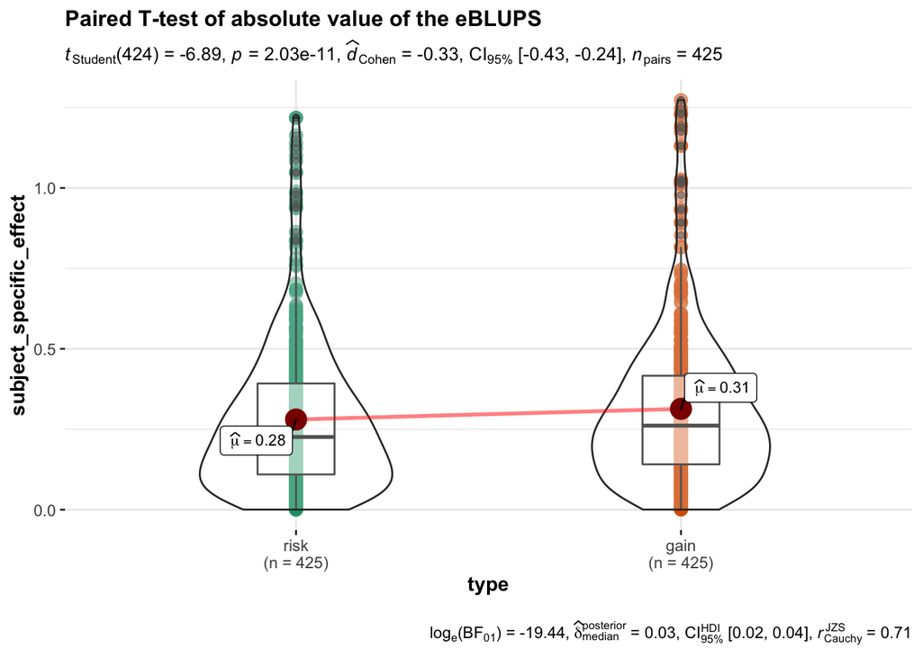

```
## # A tibble: 2 x 4
##   type  median  mean    sd
## * <fct>  <dbl> <dbl> <dbl>
## 1 risk   0.226 0.280 0.236
## 2 gain   0.261 0.313 0.245
```

**##Interdomain stability**

| condition | eBLUPs_risk | sd_risk | eBLUPs_gain | sd_gain |
| --- | --- | --- | --- | --- |
| Attention (Concentration) | -0.258 | 0.278 | 0.327 | 0.267 |
| Language (spoken) | -0.231 | 0.302 | 0.295 | 0.287 |
| Long Term Memory | -0.233 | 0.279 | 0.284 | 0.262 |
| Mood | -0.245 | 0.217 | 0.301 | 0.202 |
| Motor Function | -0.252 | 0.306 | 0.322 | 0.282 |
| Self-control | -0.235 | 0.268 | 0.292 | 0.246 |
| Short Term (Working) Memory | -0.225 | 0.296 | 0.299 | 0.268 |

```
## Multiple parameters; naming those columns num.df, den.df
## Multiple parameters; naming those columns num.df, den.df
```

one way anova testing cognitve domain; (Risk and Gain)

| num.df | den.df | statistic | p.value | method |
| --- | --- | --- | --- | --- |
| 6 | 418 | 0.1111601 | 0.9951235 | One-way analysis of means |
| 6 | 418 | 0.2267709 | 0.9679586 | One-way analysis of means |

**##Do people use nonlinear weighting of probabilities?**

[output not shown]

Model Comparison

| term | npar | AIC | BIC | logLik | deviance | statistic | df | p.value |
| --- | --- | --- | --- | --- | --- | --- | --- | --- |
| glmm.1 | 9 | 37830.58 | 37905.75 | -18906.29 | 37812.58 |  |  |  |
| glmm.2 | 10 | 37830.61 | 37914.12 | -18905.30 | 37810.61 | 1.978 | 1 | 0.160 |
| glmm.3 | 11 | 37831.01 | 37922.87 | -18904.50 | 37809.01 | 1.601 | 1 | 0.206 |
| glmm.4 | 12 | 37830.51 | 37930.73 | -18903.26 | 37806.51 | 2.495 | 1 | 0.114 |
| glmm.5 | 13 | 37771.79 | 37880.36 | -18872.89 | 37745.79 | 60.724 | 1 | 0.000 |
| glmm.6 | 14 | 37759.58 | 37876.50 | -18865.79 | 37731.58 | 14.204 | 1 | 0.000 |
| glmm.7 | 15 | 37760.43 | 37885.70 | -18865.21 | 37730.43 | 1.155 | 1 | 0.283 |

**Table 1:** main effects for logistic regression with random effects

|  | Main effects |  |  |  | Polynomials |  |  |  | Interactions |  |  |  |
| --- | --- | --- | --- | --- | --- | --- | --- | --- | --- | --- | --- | --- |
| Ind. Variable | Odds Ratios | CI | Statistic | p | Odds Ratios | CI | Statistic | p | Odds Ratios | CI | Statistic | p |
| (Intercept) | 0.66 | 0.61 – 0.72 | -9.86 | **<0.001** | 0.66 | 0.60 – 0.72 | -9.26 | **<0.001** | 0.64 | 0.59 – 0.71 | -9.18 | **<0.001** |
| risk | 0.79 | 0.75 – 0.82 | -10.92 | **<0.001** | 0.79 | 0.75 – 0.82 | -10.98 | **<0.001** | 0.71 | 0.68 – 0.75 | -13.20 | **<0.001** |
| gain | 1.35 | 1.30 – 1.41 | 14.26 | **<0.001** | 1.37 | 1.31 – 1.43 | 13.98 | **<0.001** | 1.49 | 1.41 – 1.57 | 14.97 | **<0.001** |
| gain^2 |  |  |  |  | 0.98 | 0.96 – 1.00 | -1.72 | 0.085 | 1.01 | 0.95 – 1.06 | 0.29 | 0.773 |
| risk^2 |  |  |  |  | 1.02 | 0.99 – 1.05 | 1.44 | 0.151 | 0.99 | 0.95 – 1.04 | -0.37 | 0.712 |
| risk * gain |  |  |  |  |  |  |  |  | 0.91 | 0.85 – 0.97 | -2.89 | **0.004** |
| risk * gain^2 |  |  |  |  |  |  |  |  | 1.05 | 1.00 – 1.10 | 2.11 | **0.035** |
| gain * risk^2 |  |  |  |  |  |  |  |  | 0.90 | 0.86 – 0.95 | -3.77 | **<0.001** |
| Random Effects |  |  |  |  |  |  |  |  |  |  |  |  |
| σ<sup>2</sup> | 3.29 |  |  |  | 3.29 |  |  |  | 3.29 |  |  |  |
| τ<sub>00</sub> | 0.68 <sub>user_id</sub> |  |  |  | 0.68 <sub>user_id</sub> |  |  |  | 0.68 <sub>user_id</sub> |  |  |  |
| τ<sub>11</sub> | 0.11 <sub>user_id.risk</sub> |  |  |  | 0.11 <sub>user_id.risk</sub> |  |  |  | 0.11 <sub>user_id.risk</sub> |  |  |  |
|  | 0.10 <sub>user_id.gain</sub> |  |  |  | 0.10 <sub>user_id.gain</sub> |  |  |  | 0.10 <sub>user_id.gain</sub> |  |  |  |
| ρ<sub>01</sub> | 0.39 |  |  |  | 0.38 |  |  |  | 0.38 |  |  |  |
|  | -0.22 |  |  |  | -0.23 |  |  |  | -0.23 |  |  |  |
| N | 425 <sub>user_id</sub> |  |  |  | 425 <sub>user_id</sub> |  |  |  | 425 <sub>user_id</sub> |  |  |  |
| Observations | 31305 |  |  |  | 31305 |  |  |  | 31305 |  |  |  |
| Marginal R<sup>2</sup> / Conditional R<sup>2</sup> | 0.049 / 0.265 |  |  |  | 0.049 / 0.265 |  |  |  | 0.051 / 0.265 |  |  |  |
| AIC | 37830.584 |  |  |  | 37831.006 |  |  |  | 37759.583 |  |  |  |

*Note:* Standardized parameters were obtained by fitting the model on a standardized version of the dataset. 95% Confidence Intervals (CIs) and p-values were computed using Satterthwaite approximation.

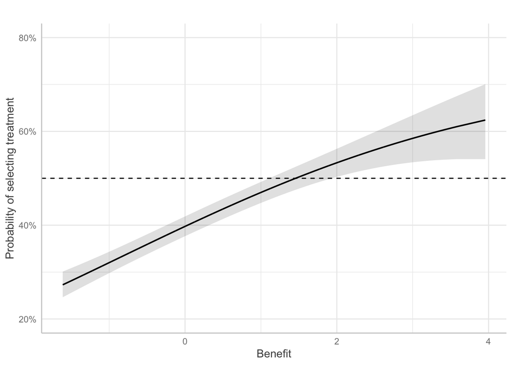

```
## JOHNSON-NEYMAN INTERVAL
##
## When gain is OUTSIDE the interval [-10.26, -2.13], the slope of risk is p <
## .05.
##
## Note: The range of observed values of gain is [-1.61, 3.96]
```

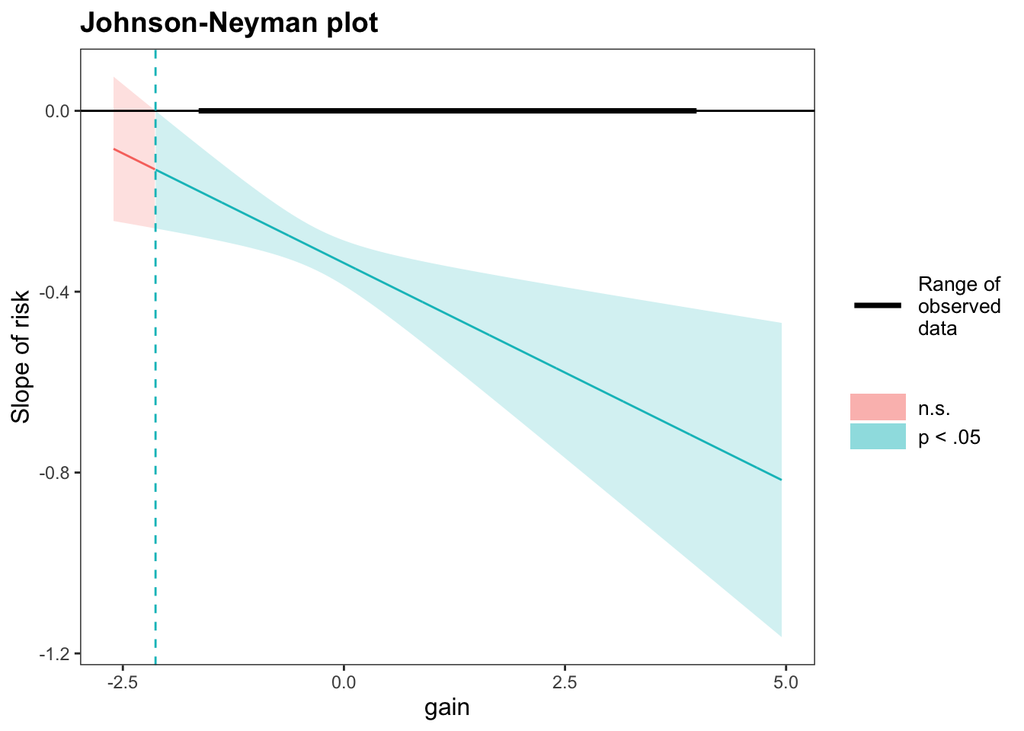

```
## SIMPLE SLOPES ANALYSIS
##
## When gain = -1.00:
##
##                                Est.   S.E.    2.5%   97.5%   z val.      p
## --------------------------- ------- ------ ------- ------- -------- ------
## Slope of risk                 -0.19   0.03   -0.24   -0.14    -7.10   0.00
## Conditional intercept         -0.83   0.06   -0.94   -0.72   -14.91   0.00
##
## When gain =  0.00:
##
##                                Est.   S.E.    2.5%   97.5%   z val.      p
## --------------------------- ------- ------ ------- ------- -------- ------
## Slope of risk                 -0.34   0.03   -0.39   -0.29   -13.20   0.00
## Conditional intercept         -0.44   0.05   -0.53   -0.35    -9.18   0.00
##
## When gain =  1.00:
##
##                                Est.   S.E.    2.5%   97.5%   z val.      p
## --------------------------- ------- ------ ------- ------- -------- ------
## Slope of risk                 -0.38   0.06   -0.51   -0.26    -6.06   0.00
## Conditional intercept         -0.03   0.05   -0.13    0.06    -0.70   0.48
```

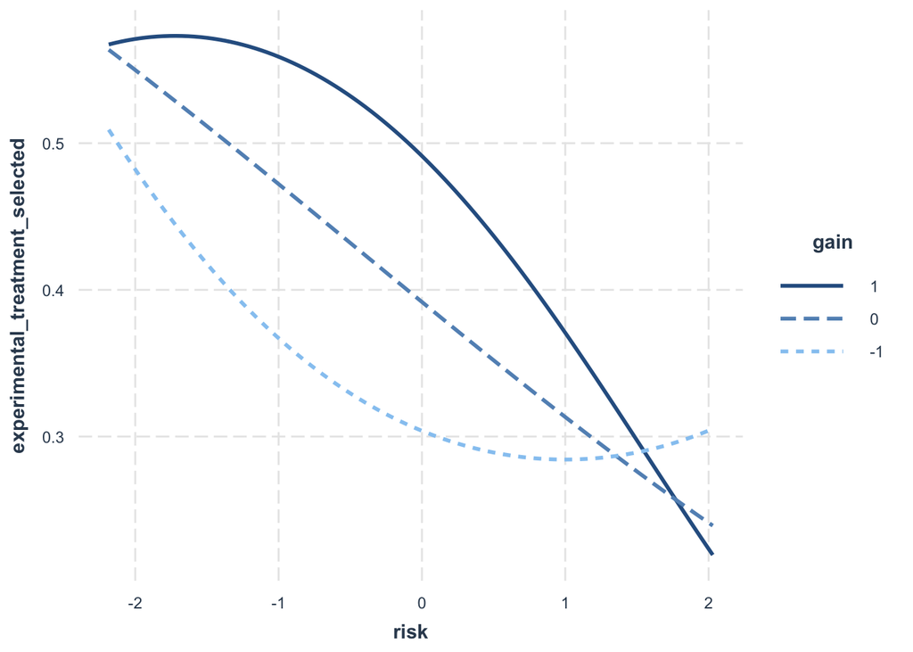

```
##   Est. S.E. 2.5% 97.5%
## 1  -17    3  -21   -13
## 2  -29    3  -32   -25
## 3  -32    7  -40   -23
```

```
## JOHNSON-NEYMAN INTERVAL
##
## When risk is OUTSIDE the interval [2.36, 12.95], the slope of gain is p <
## .05.
##
## Note: The range of observed values of risk is [-2.19, 2.03]
```

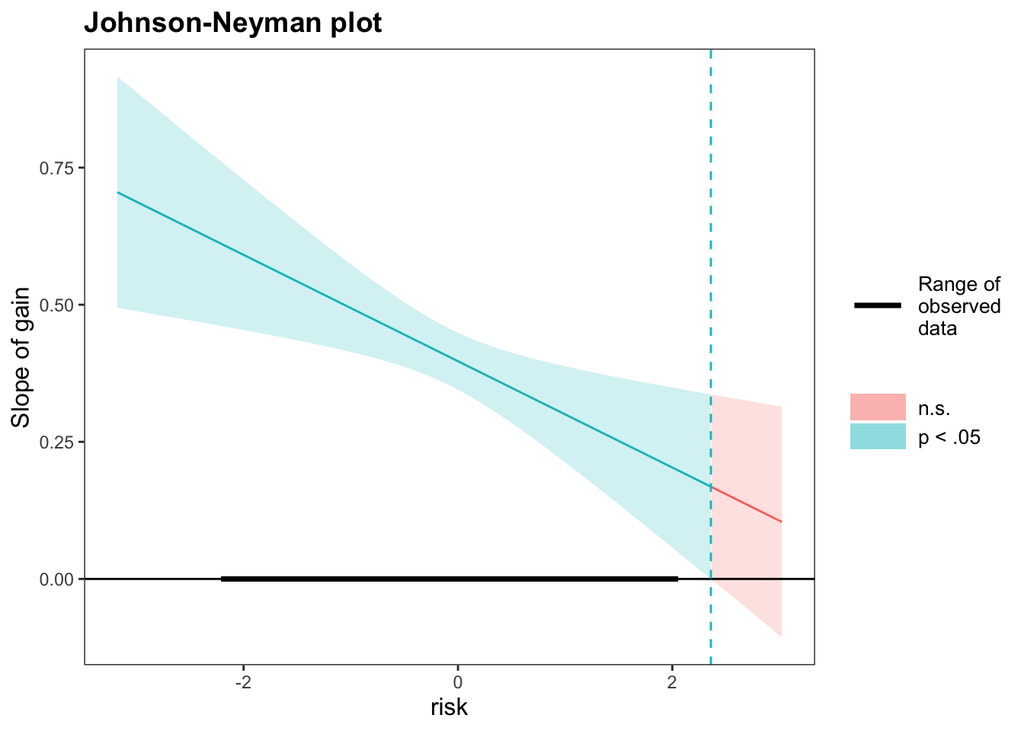

```
## SIMPLE SLOPES ANALYSIS
##
## When risk = -1.00:
##
##                                Est.   S.E.    2.5%   97.5%   z val.      p
## --------------------------- ------- ------ ------- ------- -------- ------
## Slope of gain                  0.39   0.03    0.34    0.44    14.21   0.00
## Conditional intercept         -0.11   0.04   -0.20   -0.02    -2.51   0.01
##
## When risk =  0.00:
##
##                                Est.   S.E.    2.5%   97.5%   z val.      p
## --------------------------- ------- ------ ------- ------- -------- ------
## Slope of gain                  0.40   0.03    0.35    0.45    14.97   0.00
## Conditional intercept         -0.44   0.05   -0.53   -0.35    -9.18   0.00
##
## When risk =  1.00:
##
##                                Est.   S.E.    2.5%   97.5%   z val.      p
## --------------------------- ------- ------ ------- ------- -------- ------
## Slope of gain                  0.20   0.06    0.08    0.32     3.24   0.00
## Conditional intercept         -0.78   0.06   -0.90   -0.67   -13.81   0.00
```

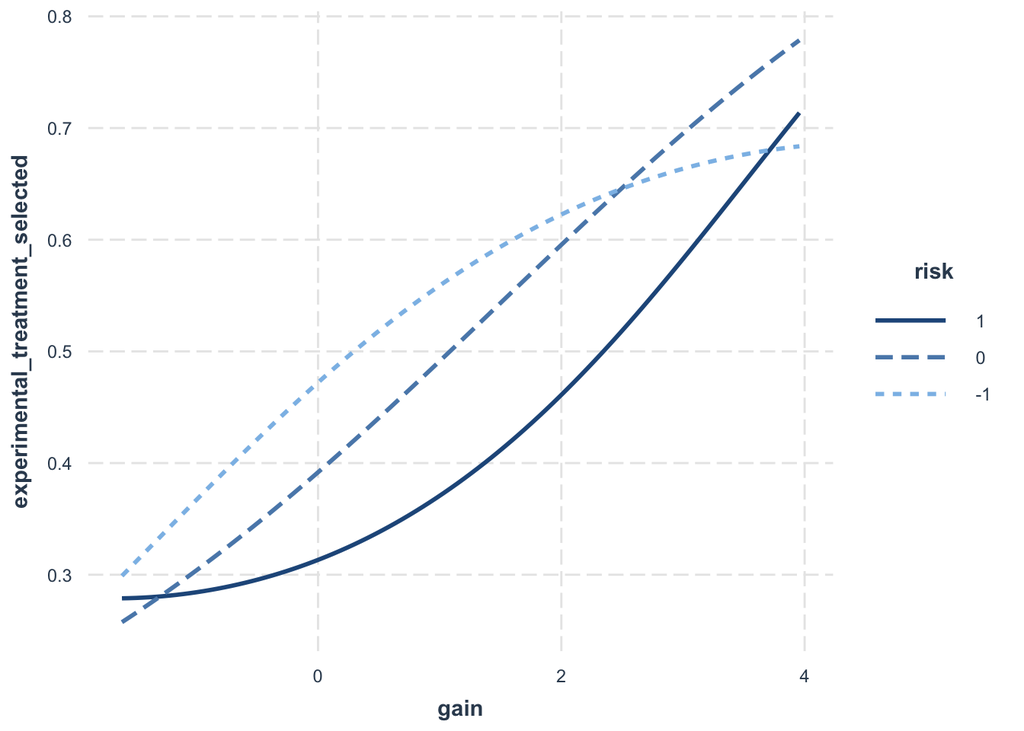

```
##   Est. S.E. 2.5% 97.5%
## 1   48    3   40    56
## 2   49    3   41    57
## 3   22    6    8    37
```

| Parameter | Coefficient | SE | CI_low | CI_high | z | p |
| --- | --- | --- | --- | --- | --- | --- |
| risk | -0.3365914 | 0.0254954 | -0.3865614 | -0.2866214 | -13.2020612 | 0.0000000 |
| gain | 0.3969912 | 0.0265201 | 0.3450129 | 0.4489696 | 14.9694744 | 0.0000000 |
| I(gain^2) | 0.0080872 | 0.0279756 | -0.0467439 | 0.0629183 | 0.2890793 | 0.7725207 |
| I(risk^2) | -0.0082542 | 0.0223586 | -0.0520761 | 0.0355678 | -0.3691722 | 0.7119994 |
| risk:gain | -0.0969448 | 0.0335734 | -0.1627474 | -0.0311421 | -2.8875468 | 0.0038826 |
| risk:I(gain^2) | 0.0505478 | 0.0239732 | 0.0035612 | 0.0975344 | 2.1085131 | 0.0349866 |
| gain:I(risk^2) | -0.1029927 | 0.0273093 | -0.1565180 | -0.0494675 | -3.7713418 | 0.0001624 |

|  | Model 1 |  |  |  | Model 2 |  |  |  | Model 3 |  |  |  | Model 4 |  |  |  | Model 5 |  |  |  | Model 6 |  |  |  | Model 7 |  |  |  |
| --- | --- | --- | --- | --- | --- | --- | --- | --- | --- | --- | --- | --- | --- | --- | --- | --- | --- | --- | --- | --- | --- | --- | --- | --- | --- | --- | --- | --- |
| Ind. Variable | Odds Ratios | CI | Statistic | p | Odds Ratios | CI | Statistic | p | Odds Ratios | CI | Statistic | p | Odds Ratios | CI | Statistic | p | Odds Ratios | CI | Statistic | p | Odds Ratios | CI | Statistic | p | Odds Ratios | CI | Statistic | p |
| (Intercept) | 0.660 | 0.608 – 0.717 | -9.860 | **<0.001** | 0.670 | 0.616 – 0.730 | -9.198 | **<0.001** | 0.660 | 0.604 – 0.720 | -9.262 | **<0.001** | 0.667 | 0.610 – 0.729 | -8.935 | **<0.001** | 0.617 | 0.563 – 0.676 | -10.367 | **<0.001** | 0.644 | 0.586 – 0.708 | -9.182 | **<0.001** | 0.649 | 0.590 – 0.713 | -8.951 | **<0.001** |
| risk | 0.787 | 0.753 – 0.821 | -10.919 | **<0.001** | 0.784 | 0.751 – 0.819 | -10.997 | **<0.001** | 0.785 | 0.752 – 0.820 | -10.980 | **<0.001** | 0.775 | 0.740 – 0.811 | -10.797 | **<0.001** | 0.731 | 0.696 – 0.767 | -12.654 | **<0.001** | 0.714 | 0.679 – 0.751 | -13.202 | **<0.001** | 0.712 | 0.677 – 0.749 | -13.238 | **<0.001** |
| gain | 1.353 | 1.298 – 1.410 | 14.262 | **<0.001** | 1.367 | 1.308 – 1.429 | 13.927 | **<0.001** | 1.372 | 1.312 – 1.434 | 13.982 | **<0.001** | 1.353 | 1.290 – 1.419 | 12.488 | **<0.001** | 1.452 | 1.381 – 1.527 | 14.533 | **<0.001** | 1.487 | 1.412 – 1.567 | 14.969 | **<0.001** | 1.504 | 1.423 – 1.590 | 14.416 | **<0.001** |
| gain^2 |  |  |  |  | 0.983 | 0.961 – 1.006 | -1.419 | 0.156 | 0.979 | 0.956 – 1.003 | -1.722 | 0.085 | 0.964 | 0.935 – 0.994 | -2.333 | **0.020** | 1.080 | 1.036 – 1.126 | 3.616 | **<0.001** | 1.008 | 0.954 – 1.065 | 0.289 | 0.773 | 1.003 | 0.949 – 1.061 | 0.117 | 0.907 |
| risk^2 |  |  |  |  |  |  |  |  | 1.022 | 0.992 – 1.052 | 1.436 | 0.151 | 1.009 | 0.976 – 1.043 | 0.518 | 0.605 | 1.045 | 1.009 – 1.081 | 2.492 | **0.013** | 0.992 | 0.949 – 1.036 | -0.369 | 0.712 | 0.985 | 0.941 – 1.031 | -0.659 | 0.510 |
| risk * gain |  |  |  |  |  |  |  |  |  |  |  |  | 0.964 | 0.921 – 1.009 | -1.583 | 0.113 | 0.993 | 0.948 – 1.040 | -0.308 | 0.758 | 0.908 | 0.850 – 0.969 | -2.888 | **0.004** | 0.924 | 0.859 – 0.995 | -2.101 | **0.036** |
| risk * gain^2 |  |  |  |  |  |  |  |  |  |  |  |  |  |  |  |  | 1.128 | 1.095 – 1.162 | 7.946 | **<0.001** | 1.052 | 1.004 – 1.102 | 2.109 | **0.035** | 1.073 | 1.012 – 1.139 | 2.354 | **0.019** |
| gain * risk^2 |  |  |  |  |  |  |  |  |  |  |  |  |  |  |  |  |  |  |  |  | 0.902 | 0.855 – 0.952 | -3.771 | **<0.001** | 0.906 | 0.859 – 0.957 | -3.564 | **<0.001** |
| gain^2 * risk^2 |  |  |  |  |  |  |  |  |  |  |  |  |  |  |  |  |  |  |  |  |  |  |  |  | 1.018 | 0.986 – 1.052 | 1.114 | 0.265 |
| Random Effects |  |  |  |  |  |  |  |  |  |  |  |  |  |  |  |  |  |  |  |  |  |  |  |  |  |  |  |  |
| σ<sup>2</sup> | 3.29 |  |  |  | 3.29 |  |  |  | 3.29 |  |  |  | 3.29 |  |  |  | 3.29 |  |  |  | 3.29 |  |  |  | 3.29 |  |  |  |
| τ<sub>00</sub> | 0.68 <sub>user_id</sub> |  |  |  | 0.68 <sub>user_id</sub> |  |  |  | 0.68 <sub>user_id</sub> |  |  |  | 0.68 <sub>user_id</sub> |  |  |  | 0.68 <sub>user_id</sub> |  |  |  | 0.68 <sub>user_id</sub> |  |  |  | 0.68 <sub>user_id</sub> |  |  |  |
| τ<sub>11</sub> | 0.11 <sub>user_id.risk</sub> |  |  |  | 0.11 <sub>user_id.risk</sub> |  |  |  | 0.11 <sub>user_id.risk</sub> |  |  |  | 0.11 <sub>user_id.risk</sub> |  |  |  | 0.11 <sub>user_id.risk</sub> |  |  |  | 0.11 <sub>user_id.risk</sub> |  |  |  | 0.11 <sub>user_id.risk</sub> |  |  |  |
|  | 0.10 <sub>user_id.gain</sub> |  |  |  | 0.10 <sub>user_id.gain</sub> |  |  |  | 0.10 <sub>user_id.gain</sub> |  |  |  | 0.10 <sub>user_id.gain</sub> |  |  |  | 0.10 <sub>user_id.gain</sub> |  |  |  | 0.10 <sub>user_id.gain</sub> |  |  |  | 0.10 <sub>user_id.gain</sub> |  |  |  |
| ρ<sub>01</sub> | 0.39 |  |  |  | 0.39 |  |  |  | 0.38 |  |  |  | 0.38 |  |  |  | 0.38 |  |  |  | 0.38 |  |  |  | 0.39 |  |  |  |
|  | -0.22 |  |  |  | -0.23 |  |  |  | -0.23 |  |  |  | -0.23 |  |  |  | -0.22 |  |  |  | -0.23 |  |  |  | -0.23 |  |  |  |
| ICC | 0.23 |  |  |  | 0.23 |  |  |  | 0.23 |  |  |  | 0.23 |  |  |  | 0.23 |  |  |  | 0.23 |  |  |  | 0.23 |  |  |  |
| N | 425 <sub>user_id</sub> |  |  |  | 425 <sub>user_id</sub> |  |  |  | 425 <sub>user_id</sub> |  |  |  | 425 <sub>user_id</sub> |  |  |  | 425 <sub>user_id</sub> |  |  |  | 425 <sub>user_id</sub> |  |  |  | 425 <sub>user_id</sub> |  |  |  |
| Observations | 31305 |  |  |  | 31305 |  |  |  | 31305 |  |  |  | 31305 |  |  |  | 31305 |  |  |  | 31305 |  |  |  | 31305 |  |  |  |
| Marginal R<sup>2</sup> / Conditional R<sup>2</sup> | 0.049 / 0.265 |  |  |  | 0.049 / 0.265 |  |  |  | 0.049 / 0.265 |  |  |  | 0.049 / 0.265 |  |  |  | 0.050 / 0.265 |  |  |  | 0.051 / 0.265 |  |  |  | 0.051 / 0.265 |  |  |  |

#Individual Differences

Note I have run these without the outliers and with; no practical difference. ##**Age**

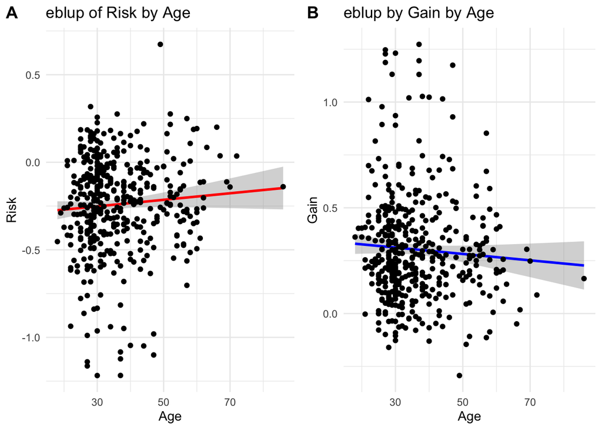

| **Characteristic** | **Beta** | **95% CI**<sup>1</sup> | **p-value** |
| --- | --- | --- | --- |
| age | 0.00 | 0.00, 0.00 | 0.13 |

<sup>*1*</sup> CI = Confidence Interval

| **Characteristic** | **Beta** | **95% CI**<sup>1</sup> | **p-value** |
| --- | --- | --- | --- |
| age | 0.00 | 0.00, 0.00 | 0.2 |

<sup>*1*</sup> CI = Confidence Interval

**We did not find any individual differenece in risk or gain as a function of age**

##**Education**

Descriptives for risk by education

| education | n | mean | sd | se | ci |
| --- | --- | --- | --- | --- | --- |
| Undergraduate | 242 | -0.2206906 | 0.2671057 | 0.0171702 | 0.0338228 |
| Postgraduate | 68 | -0.1392074 | 0.2942031 | 0.0356774 | 0.0712123 |
| HighSchool | 114 | -0.3362543 | 0.2540821 | 0.0237970 | 0.0471461 |

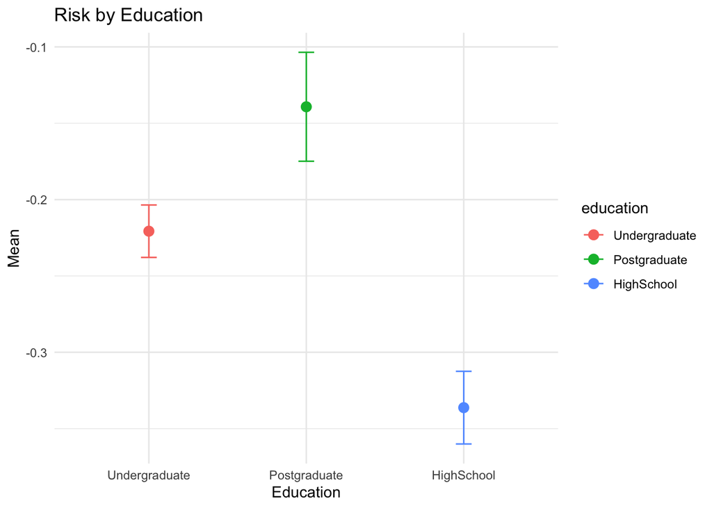

Descriptives for gain by education

| education | n | mean | sd | se | ci |
| --- | --- | --- | --- | --- | --- |
| Undergraduate | 242 | 0.2863777 | 0.2491340 | 0.0160149 | 0.0315471 |
| Postgraduate | 68 | 0.2155908 | 0.2829406 | 0.0343116 | 0.0684862 |
| HighSchool | 114 | 0.3833746 | 0.2382061 | 0.0223100 | 0.0442002 |

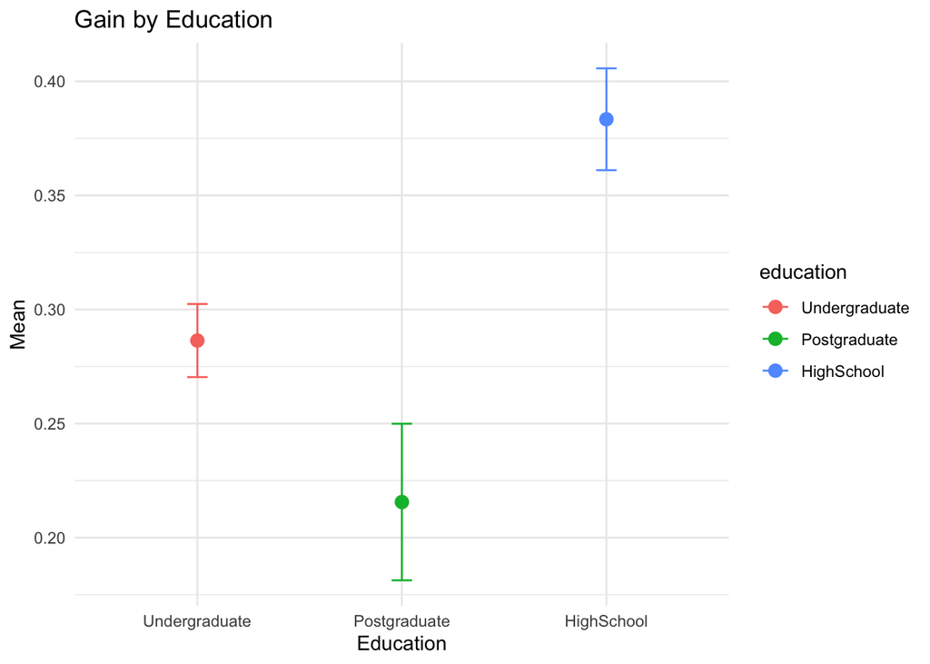

[figure not shown]

Predicting Risk given Categorical Education

| term | estimate | std.error | statistic | p.value |
| --- | --- | --- | --- | --- |
| (Intercept) | -0.221 | 0.017 | -12.800 | 0.000 |
| educationPostgraduate | 0.081 | 0.037 | 2.213 | 0.027 |
| educationHighSchool | -0.116 | 0.030 | -3.793 | 0.000 |

pairwise comparaisions of eblup for risk by education

| contrast | estimate | std.error | df | statistic | adj.p.value |
| --- | --- | --- | --- | --- | --- |
| Undergraduate - Postgraduate | -0.081 | 0.037 | 421 | -2.213 | 0.070 |
| Undergraduate - HighSchool | 0.116 | 0.030 | 421 | 3.793 | 0.001 |
| Postgraduate - HighSchool | 0.197 | 0.041 | 421 | 4.794 | 0.000 |

Predicting Gain given Categorical Education

| term | estimate | std.error | statistic | p.value |
| --- | --- | --- | --- | --- |
| (Intercept) | 0.286 | 0.016 | 17.679 | 0.000 |
| educationPostgraduate | -0.071 | 0.035 | -2.047 | 0.041 |
| educationHighSchool | 0.097 | 0.029 | 3.388 | 0.001 |

pairwise comparaisions of eblup for gain by education

| contrast | estimate | std.error | df | statistic | adj.p.value |
| --- | --- | --- | --- | --- | --- |
| Undergraduate - Postgraduate | 0.071 | 0.035 | 421 | 2.047 | 0.103 |
| Undergraduate - HighSchool | -0.097 | 0.029 | 421 | -3.388 | 0.002 |
| Postgraduate - HighSchool | -0.168 | 0.039 | 421 | -4.345 | 0.000 |

Predicting eblup given R/B and education

| term | estimate | std.error | statistic | p.value |
| --- | --- | --- | --- | --- |
| (Intercept) | -0.221 | 0.017 | -13.192 | 0.000 |
| typegain | 0.507 | 0.024 | 21.433 | 0.000 |
| educationPostgraduate | 0.081 | 0.036 | 2.281 | 0.023 |
| educationHighSchool | -0.116 | 0.030 | -3.909 | 0.000 |
| typegain:educationPostgraduate | -0.152 | 0.051 | -3.014 | 0.003 |
| typegain:educationHighSchool | 0.213 | 0.042 | 5.084 | 0.000 |

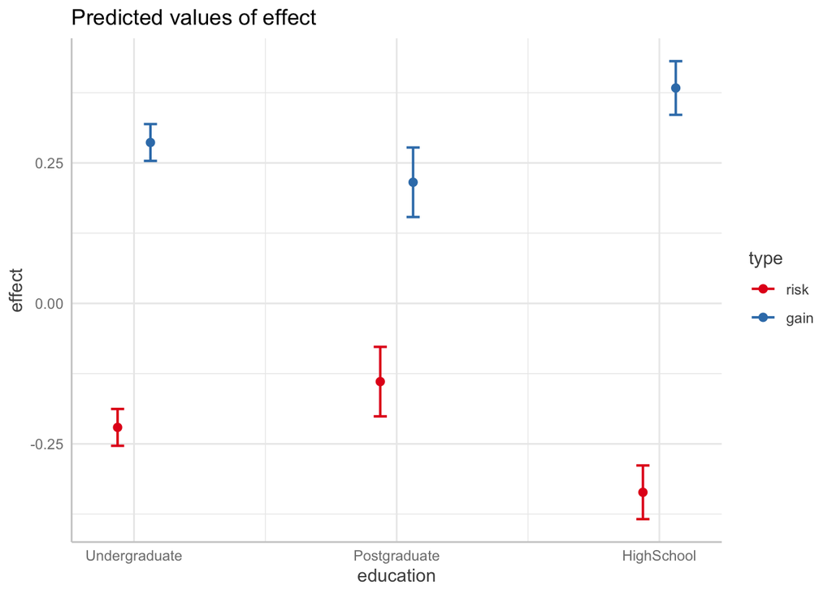

WE found a significant difference between high school and postgrad

##**Income**

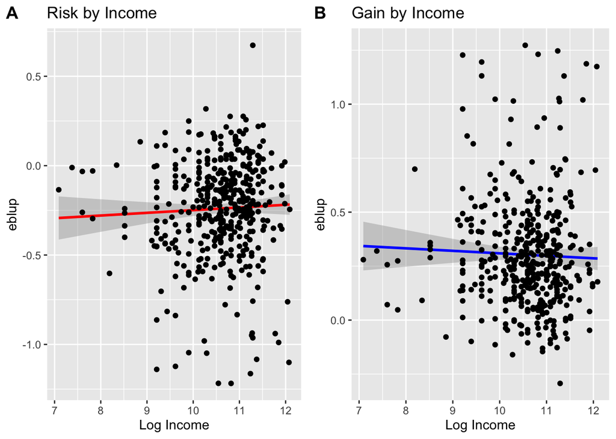

| **Characteristic** | **Beta** | **95% CI**<sup>1</sup> | **p-value** |
| --- | --- | --- | --- |
| Income | 0.02 | -0.02, 0.05 | 0.4 |

<sup>*1*</sup> CI = Confidence Interval

| **Characteristic** | **Beta** | **95% CI**<sup>1</sup> | **p-value** |
| --- | --- | --- | --- |
| Income | -0.01 | -0.04, 0.02 | 0.5 |

<sup>*1*</sup> CI = Confidence Interval

**We did not find any individual differenece in risk or gain as a function of log Income**

##**Sex**

Descriptives for risk by sex

| sex | n | mean | sd | se | ci |
| --- | --- | --- | --- | --- | --- |
| Female | 176 | -0.27 | 0.29 | 0.02 | 0.04 |
| Male | 244 | -0.22 | 0.27 | 0.02 | 0.03 |

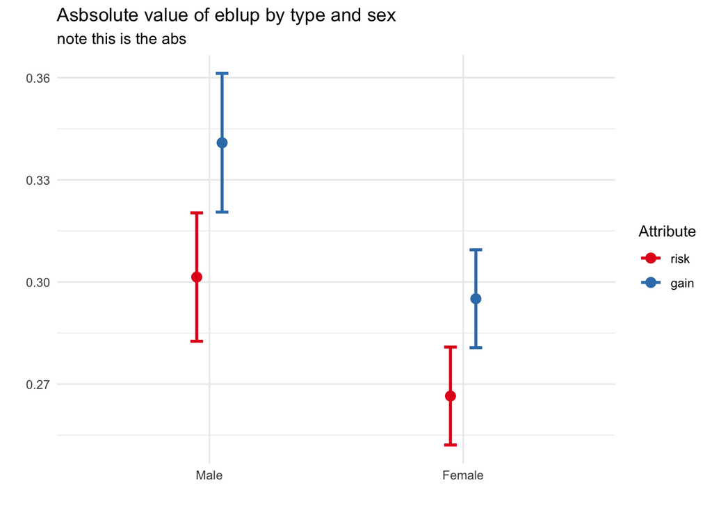

Predicting Risk given Categorical sex

| term | estimate | std.error | statistic | p.value |
| --- | --- | --- | --- | --- |
| (Intercept) | -0.2664345 | 0.0208636 | -12.770298 | 0.0000000 |
| sexMale | 0.0446543 | 0.0273728 | 1.631339 | 0.1035719 |

Predicting Gain given Categorical sex

| term | estimate | std.error | statistic | p.value |
| --- | --- | --- | --- | --- |
| (Intercept) | 0.3311969 | 0.0194839 | 16.998502 | 0.0000000 |
| sexMale | -0.0485042 | 0.0255626 | -1.897467 | 0.0584551 |

Predicting eblup given R/B and sex

| term | estimate | std.error | statistic | p.value |
| --- | --- | --- | --- | --- |
| (Intercept) | -0.2664345 | 0.0201855 | -13.199274 | 0.0000000 |
| typegain | 0.5976314 | 0.0285467 | 20.935245 | 0.0000000 |
| sexMale | 0.0446543 | 0.0264832 | 1.686139 | 0.0921422 |
| typegain:sexMale | -0.0931586 | 0.0374529 | -2.487354 | 0.0130637 |

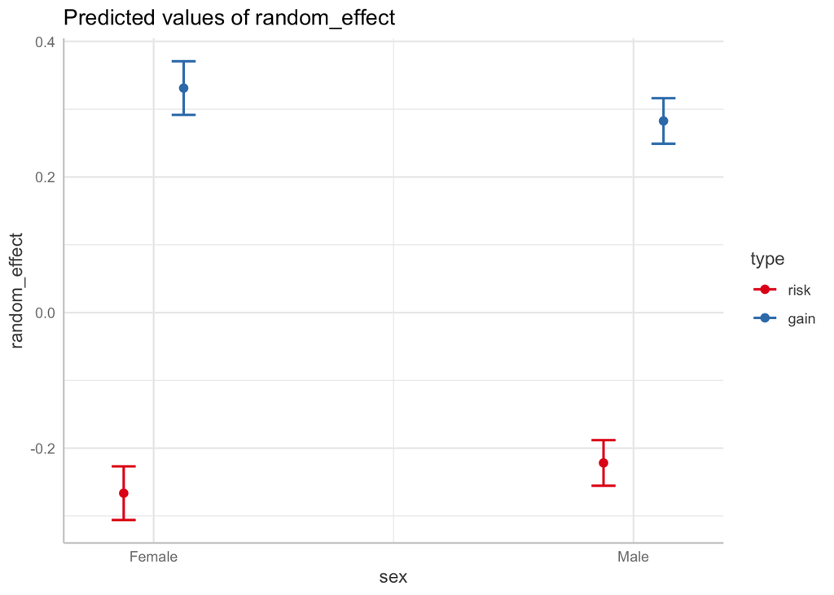

##**Race**

Descriptives for risk by race

| race_ethnicity | n | mean | sd | se | ci |
| --- | --- | --- | --- | --- | --- |
| Non-White | 130 | -0.24 | 0.30 | 0.03 | 0.05 |
| White | 292 | -0.24 | 0.27 | 0.02 | 0.03 |

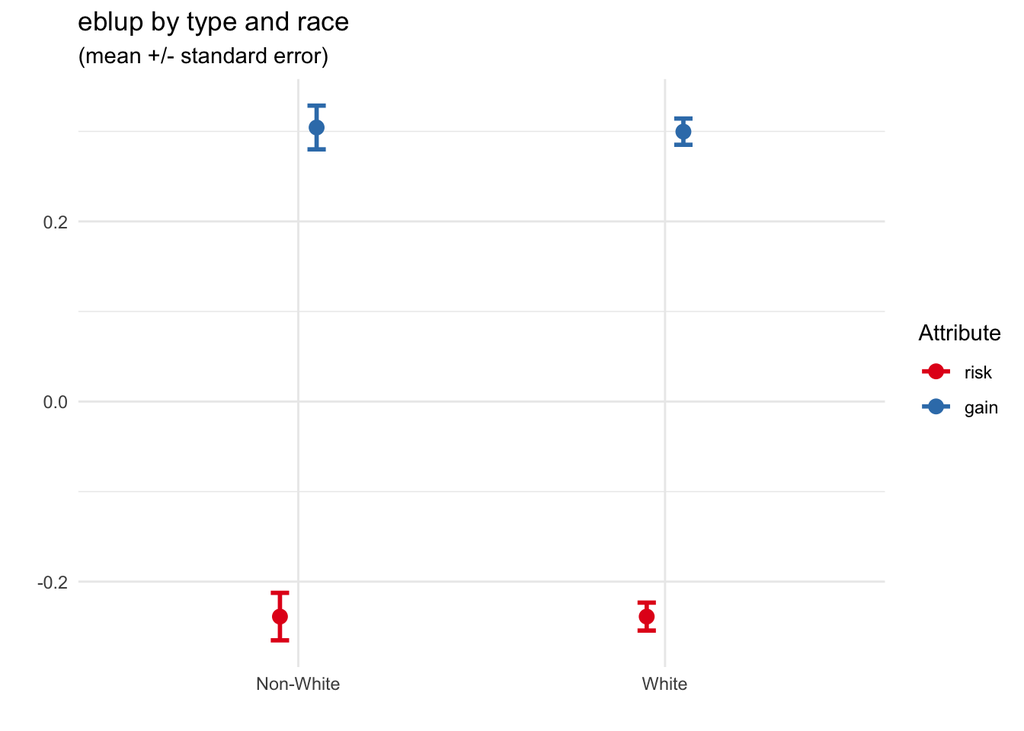

Predicting Risk given Categorical race_ethnicity

| term | estimate | std.error | statistic | p.value |
| --- | --- | --- | --- | --- |
| (Intercept) | -0.2388001 | 0.0242532 | -9.846131 | 0.0000000 |
| race_ethnicityWhite | -0.0000176 | 0.0291564 | -0.000603 | 0.9995192 |

Predicting Gain given Categorical race_ethnicity

| term | estimate | std.error | statistic | p.value |
| --- | --- | --- | --- | --- |
| (Intercept) | 0.3043193 | 0.0226132 | 13.4576077 | 0.0000000 |
| race_ethnicityWhite | -0.0046240 | 0.0271848 | -0.1700962 | 0.8650164 |

Predicting eblup given R/B and race_ethnicity

| term | estimate | std.error | statistic | p.value |
| --- | --- | --- | --- | --- |
| (Intercept) | -0.2388001 | 0.0234475 | -10.1844454 | 0.0000000 |
| typegain | 0.5431194 | 0.0331598 | 16.3788441 | 0.0000000 |
| race_ethnicityWhite | -0.0000176 | 0.0281878 | -0.0006237 | 0.9995025 |
| typegain:race_ethnicityWhite | -0.0046065 | 0.0398636 | -0.1155553 | 0.9080326 |

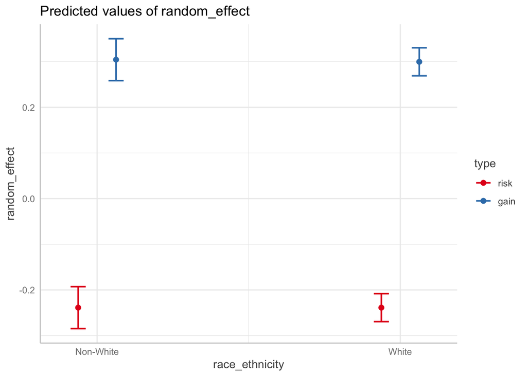

#suppTable S3

For each state the model formula, results and fixed effect terms:

| x |
| --- |
| glmer, experimental_treatment_selected ~ risk + gain + (risk + gain \| user_id), GLMM_data, binomial(link = “logit”), glmerControl(optimizer = “bobyqa”), 0 |

| AIC | BIC | logLik | deviance | df.residual |
| --- | --- | --- | --- | --- |
| 37830.58 | 37905.75 | -18906.29 | 35362.87 | 31296 |

| term | estimate | std.error | statistic | p.value |
| --- | --- | --- | --- | --- |
| (Intercept) | -0.4149951 | 0.0420872 | -9.860366 | 0 |
| risk | -0.2400514 | 0.0219854 | -10.918680 | 0 |
| gain | 0.3023174 | 0.0211975 | 14.261935 | 0 |

| x |
| --- |
| glmer, experimental_treatment_selected ~ risk + gain + I(gain^2) + (risk + gain \| user_id), GLMM_data, binomial(link = “logit”), glmerControl(optimizer = “bobyqa”), 0 |

| AIC | BIC | logLik | deviance | df.residual |
| --- | --- | --- | --- | --- |
| 37830.61 | 37914.12 | -18905.3 | 35362.48 | 31295 |

| term | estimate | std.error | statistic | p.value |
| --- | --- | --- | --- | --- |
| (Intercept) | -0.3998286 | 0.0434687 | -9.198078 | 0.0000000 |
| risk | -0.2429492 | 0.0220918 | -10.997240 | 0.0000000 |
| gain | 0.3128536 | 0.0224643 | 13.926716 | 0.0000000 |
| I(gain^2) | -0.0167168 | 0.0117826 | -1.418760 | 0.1559689 |

| x |
| --- |
| glmer, experimental_treatment_selected ~ risk + gain + I(gain^2) + I(risk^2) + (risk + gain \| user_id), GLMM_data, binomial(link = “logit”), glmerControl(optimizer = “bobyqa”), 0 |

| AIC | BIC | logLik | deviance | df.residual |
| --- | --- | --- | --- | --- |
| 37831.01 | 37922.87 | -18904.5 | 35360.87 | 31294 |

| term | estimate | std.error | statistic | p.value |
| --- | --- | --- | --- | --- |
| (Intercept) | -0.4160910 | 0.0449257 | -9.261754 | 0.0000000 |
| risk | -0.2418012 | 0.0220227 | -10.979625 | 0.0000000 |
| gain | 0.3160609 | 0.0226045 | 13.982214 | 0.0000000 |
| I(gain^2) | -0.0209074 | 0.0121446 | -1.721541 | 0.0851527 |
| I(risk^2) | 0.0214632 | 0.0149432 | 1.436320 | 0.1509113 |

| x |
| --- |
| glmer, experimental_treatment_selected ~ risk + gain + I(gain^2) + I(risk^2) + risk:gain + (risk + gain \| user_id), GLMM_data, binomial(link = “logit”), glmerControl(optimizer = “bobyqa”), 0 |

| AIC | BIC | logLik | deviance | df.residual |
| --- | --- | --- | --- | --- |
| 37830.51 | 37930.73 | -18903.26 | 35355.32 | 31293 |

| term | estimate | std.error | statistic | p.value |
| --- | --- | --- | --- | --- |
| (Intercept) | -0.4056207 | 0.0453973 | -8.9349116 | 0.0000000 |
| risk | -0.2552422 | 0.0236411 | -10.7965413 | 0.0000000 |
| gain | 0.3023207 | 0.0242088 | 12.4880497 | 0.0000000 |
| I(gain^2) | -0.0365262 | 0.0156567 | -2.3329425 | 0.0196512 |
| I(risk^2) | 0.0087858 | 0.0169756 | 0.5175562 | 0.6047680 |
| risk:gain | -0.0369371 | 0.0233340 | -1.5829715 | 0.1134280 |

[output not shown]

| AIC | BIC | logLik | deviance | df.residual |
| --- | --- | --- | --- | --- |
| 37771.79 | 37880.36 | -18872.89 | 35294.75 | 31292 |

| term | estimate | std.error | statistic | p.value |
| --- | --- | --- | --- | --- |
| (Intercept) | -0.4825585 | 0.0465470 | -10.3671255 | 0.0000000 |
| risk | -0.3138072 | 0.0247998 | -12.6536381 | 0.0000000 |
| gain | 0.3727882 | 0.0256506 | 14.5333373 | 0.0000000 |
| I(gain^2) | 0.0766792 | 0.0212047 | 3.6161394 | 0.0002990 |
| I(risk^2) | 0.0438324 | 0.0175865 | 2.4923871 | 0.0126888 |
| risk:gain | -0.0072852 | 0.0236484 | -0.3080621 | 0.7580351 |
| risk:I(gain^2) | 0.1205379 | 0.0151701 | 7.9457532 | 0.0000000 |

[output not shown]

| AIC | BIC | logLik | deviance | df.residual |
| --- | --- | --- | --- | --- |
| 37759.58 | 37876.5 | -18865.79 | 35283.5 | 31291 |

| term | estimate | std.error | statistic | p.value |
| --- | --- | --- | --- | --- |
| (Intercept) | -0.4398731 | 0.0479056 | -9.1820852 | 0.0000000 |
| risk | -0.3365914 | 0.0254954 | -13.2020612 | 0.0000000 |
| gain | 0.3969912 | 0.0265201 | 14.9694744 | 0.0000000 |
| I(gain^2) | 0.0080872 | 0.0279756 | 0.2890793 | 0.7725207 |
| I(risk^2) | -0.0082542 | 0.0223586 | -0.3691722 | 0.7119994 |
| risk:gain | -0.0969448 | 0.0335734 | -2.8875468 | 0.0038826 |
| risk:I(gain^2) | 0.0505478 | 0.0239732 | 2.1085131 | 0.0349866 |
| gain:I(risk^2) | -0.1029927 | 0.0273093 | -3.7713418 | 0.0001624 |

[output not shown]

| AIC | BIC | logLik | deviance | df.residual |
| --- | --- | --- | --- | --- |
| 37760.43 | 37885.7 | -18865.21 | 35282.97 | 31290 |

[output not shown]